# AZ OpenGIS Data Exploration

Nathan Craig

1/21/2022

# 1 Introduction

This document is an effort to supply basic summaries and exploration of the Arizona OpenGIS Initiative for Deceased Migrants ([OGIS](https://humaneborders.info/)) Migrant Mortality [data](https://humaneborders.info/app/map.asp) using methods of reproducible research.

# 2 Data Import

Presently, the data are downloaded from the server and stored locally as a CSV file. That file is then read into R and analysis takes place in R Markdown. Ideally, the file would be retrieved directly from the server using an API request. At present, characters in the file that are returned cause import errors. This issue is resolvable with a very minor edit (see Appendix B) and will hopefully be sorted out server side in the near future. For now, circumstances dictate saving the file locally and modifying it before it can be properly read into R.

# 3 Summaries

Currently the OGIS data set contains 3,816 fatalities.

[interactive chart not shown]

Figure 3.1: Map of all fatalities in the AZ OGIS database

## 3.1 Names

One of the purposes of OGIS is to attempt identification of unidentified deceased individuals. At present, of the 3,816 fatalities in the OGIS data set, 37.63% individuals remain unidentified (n= 1,436) while 62.37% persons are identified (n= 2,380, see Appendix A).

## 3.2 Sex

Table 3.1: Table showing total number of fatalities in AZ OGIS by sex determination

| Sex | n |
| --- | --- |
| Male | 3119 |
| Female | 521 |
| Undetermined | 176 |

[interactive chart not shown]

Figure 3.2: Map of fatalities by sex for individuals whose sex was determined.

## 3.3 Age

Table 3.2: Table showing mean, standard deviation, and median ages by sex among the fatalities in the AZ OGIS

| Sex | Mean | SD | Median |
| --- | --- | --- | --- |
| Female | 29.83 | 9.86 | 30 |
| Male | 31.65 | 10.23 | 30 |

Age is undetermined for 40.91% (n= 1,561) and determined for 59.09% (n= 2,255) of the fatalities in the OGIS data set (n= 3,816). The fatalities ranged in age from 0 to 99; 109 are minors (<18) and 3 are seniors (>65). The individuals with an age of 0 are less than 1 year old. The individual whose age is reported as 99 years is skeletal remains. I do not know the reason for this aged estimation. It is removed from analysis of the Age distribution. The next oldest person is 67.

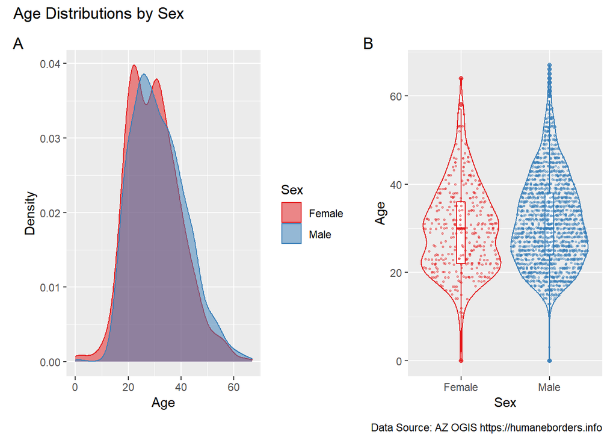

Figure 3.3: Plots of age distributions by sex among fatalities in the OGIS data base. A) is a density plot of male and female ages. B) is a violin-sina-box plot of the same distribution which helps to illustrate differences in the sizes of the two populations.

[interactive chart not shown]

Figure 3.4: Map of fatalities for which age is determined.

# 4 Reporting Date

All records have a reporting date. This makes it possible to look at annual and monthly averages.

## 4.1 Annual Summaries

Based on the entire data set, there are an average of 106 fatalities per year (SD= 84.34). A Shapiro-Wilk test finds annual average fatality counts deviate significantly from a normal distribution ($W$= 0.85, $p$= <0.01). No outliers were detected which is likely due to the high variability in annual fatalities over time (Mdn=133.50, IQR= 163.25). 2021 saw the highest number of deaths (n= 226).

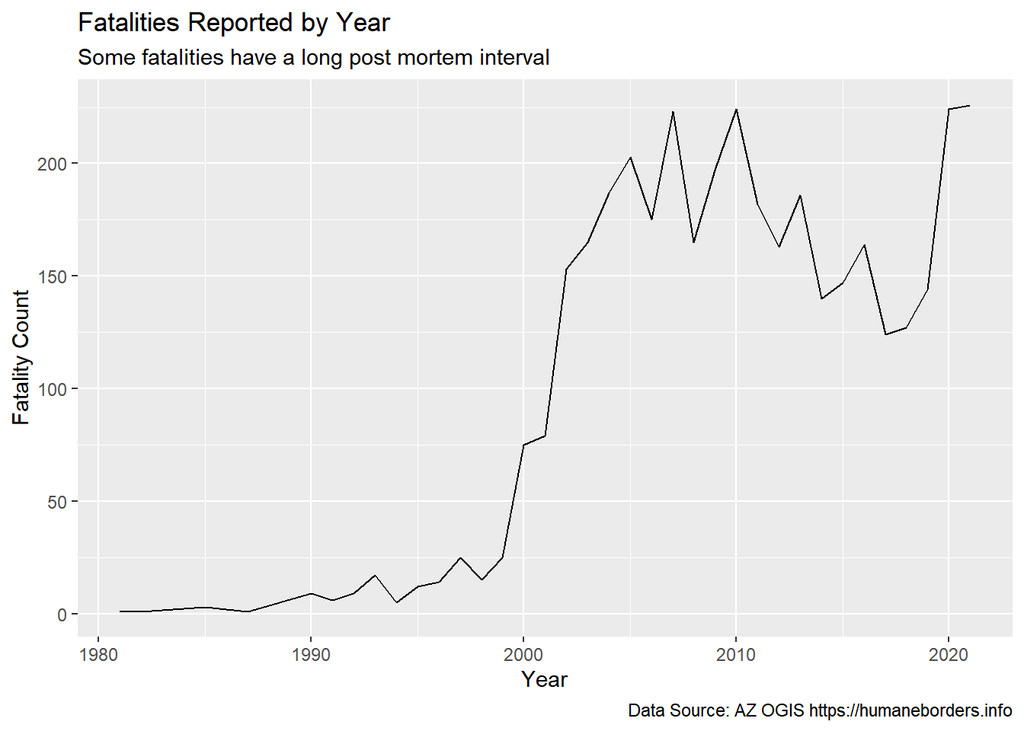

Figure 4.1: Plot of the number of fatalities reported per year. Note some fatalities occurred well prior to the reporting date.

Some fatalities indicate a long post mortem interval. Therefore, raw counts are a poor indicator of annual fatalities because some individuals were deceased more than a year. One approach to estimating trends in fatalities over time is to look only at annual averages among individuals with a comparatively “Recent” post mortem condition. Here “Recent” post mortem is defined as “< 1 day”, “< 1 week”, “< 3 weeks”, “< 5 weeks”, “< 3 months”, and “< 6-8 months”.

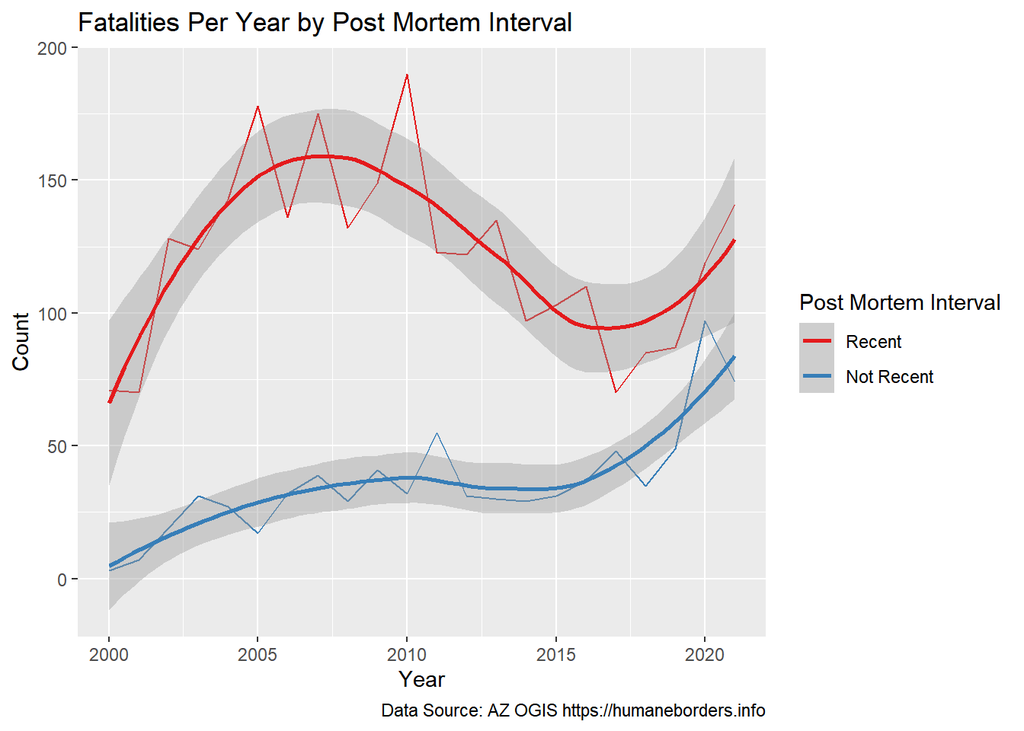

Border wall building began first in 1993 in along the San-Diego-Tijuana. In 1994 barrier construction expanded in three areas: Operation Safeguard in Arizona, Operation Gatekeeper in California, and Operation Hold-the-Line in Texas.

Yearly fatalities were calculated pre and post 1994. Prior to 1994, there were 52 fatalities over 9 years (M= 5.78, SD= 5.29). From 1994 and afterwards there are 3,769 fatalities over 28 years (M= 134.61, SD= 73.44). A Shapiro-Wilk test finds annual fatality counts are normally distributed for the pre 1994 ($W$=0.86, $p$= 0.10) but not post 1994 ($W$=0.86, $p$= <0.01) periods.

The Mann-Whitney U test is for nonparametric data and unpaired samples, and thus should be appropriate for this comparison. The Mann-Whitney test finds the pre 1994 and post 1994 yearly fatality counts are significantly different ($U$= 7.50, $p$= <0.01). On average, there are significantly more fatalities per year after the wall was built.

## 4.2 Monthly Summaries

Looking at the entire AZ OGIS data set, there are an average of 318 (SD= 147.58) fatalities reported per month. A Shapiro-Wilk normality test found the monthly count of fatalities reported is significantly different from a normal distribution ($W$= 0.79, $p$= <0.01). July has the highest average number of reported fatalities (n= 633) and is an outlier (Mdn=234, IQR= 138).

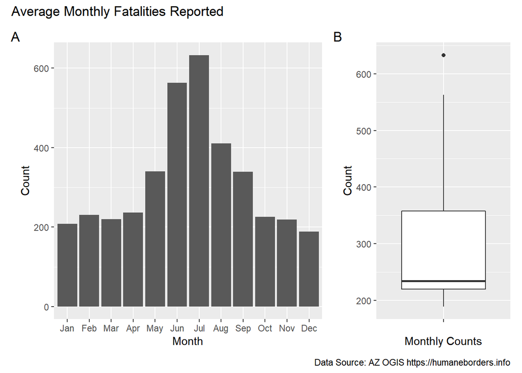

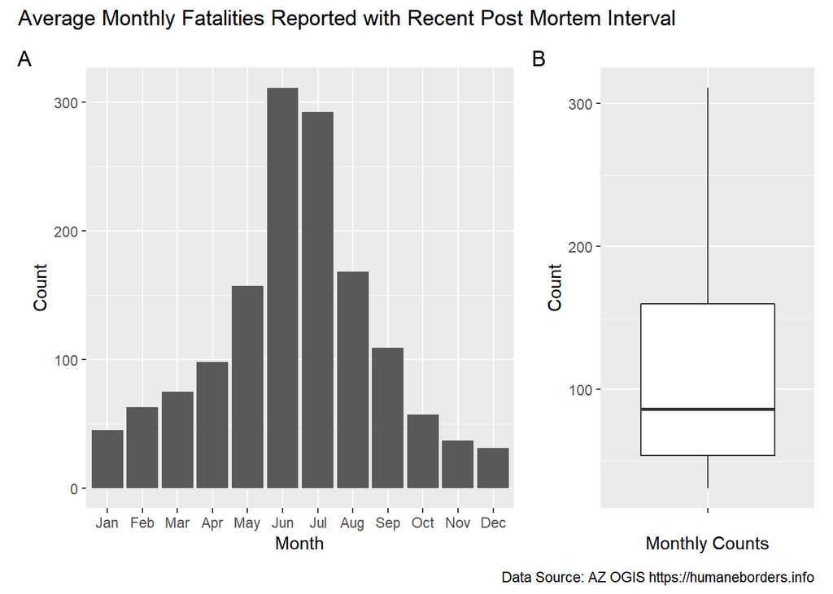

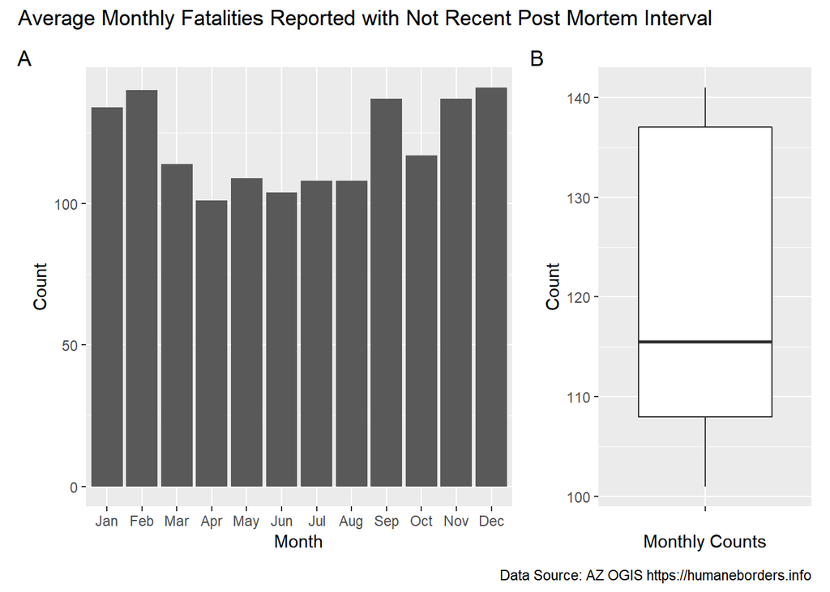

## 4.3 Monthly Fatalities in Relation to Temperature

The highest number of low post mortem interval facilitates is reported during the months of June and July. These are also the hottest months of the year. Is there a correlation between temperature and the number of fatalities?

The Pearson’s product-moment correlation found a strong positive correlation between average temperature and average reported fatalities with recent post mortem condition, $r$(10) = 0.83, $p$= <0.01. Average temperature predicts average annual fatalities with recent post moretem condition, $R^2$= 0.69, $F$(1,10) = 21.90, $p$= <0.01, adj. $R^2$= 0.66.

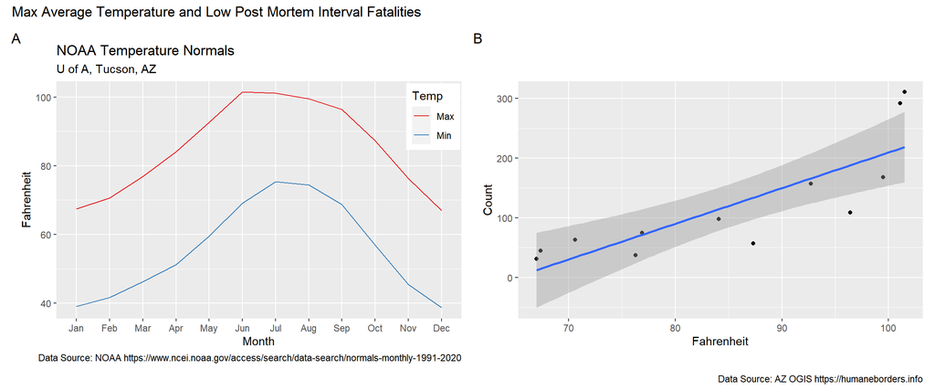

# 5 Cause of Death

| Cause of Death | n |
| --- | --- |
| Exposure | 1336 |
| Skeletal Remains | 1297 |
| Undetermined | 695 |
| Blunt Force Injury | 200 |
| Gunshot Wound | 96 |
| Drowning | 43 |
| Motor Vehicle Accident | 26 |
| Other Injury / Homicide | 26 |
| Pending | 22 |
| Heart Disease | 20 |

The various offices of medical examiners who contributed data to OGIS list 19 different causes of death. COD is Undetermined for 18.21% (n= 695) of the individuals. Additionally, Skeletal Remains are listed as COD for 33.99% (n= 1,297) of the individuals.

Unfortunately, Skeletal Remains is not a cause of death but is instead a post mortem condition of the body that results from death. While some causes of death cannot be inferred from skeletal remains, some can be determined. Therefore, unless there is other information on those individuals whose COD is listed as Skeletal Remains, they are treated as Undetermined and not further considered.

In OGIS, after filtering, this leaves 47.80% of the individuals (n= 1,824) for whom COD is determined.

Exposure, Blunt Force Injury, and Gunshot Wound are outliers while Exposure and Blunt Force Injury are extreme outliers.

Are some months more common for Exposure? Are some months more common for Skeletal Remains?

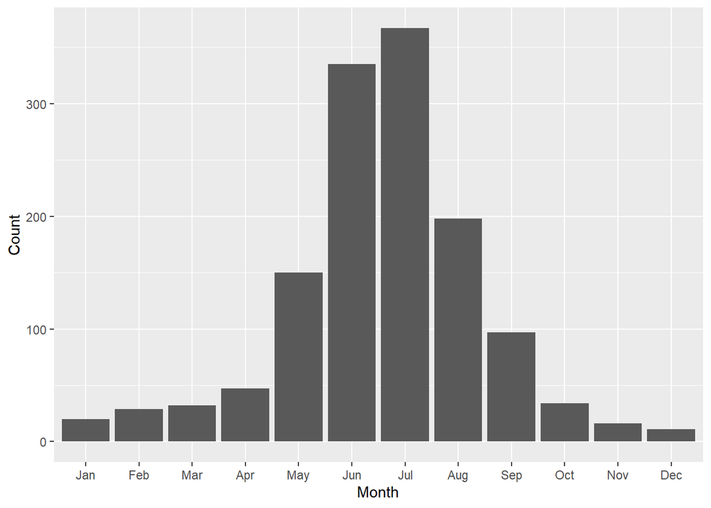

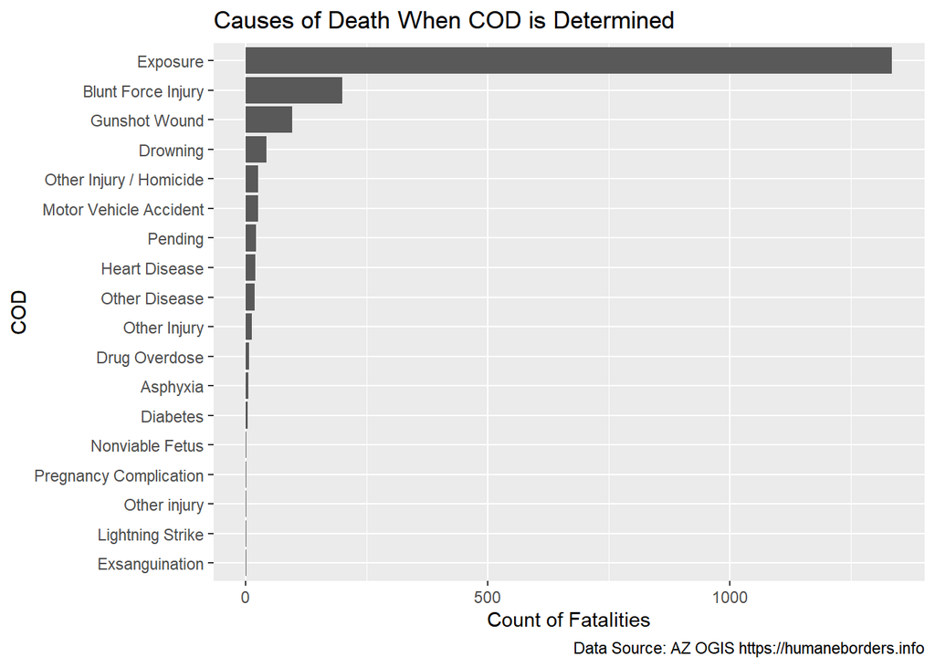

Figure 5.1: Bar chart showing, in descending order, counts by cause of death category when an individual’s COD is known.

[interactive chart not shown]

Figure 5.2: Map of fatalities showing the 10 most common causes of death.

# 6 Body Condition

| Body Condition | n |
| --- | --- |
| Fully fleshed | 1041 |
| Complete skeletonization w/ bone degradation | 793 |
| Decomposed | 402 |
| Complete skeletonization w/ disarticulation | 357 |
| Other | 335 |
| Skeletonization w/ mummification | 333 |
| Skeletonization w/ articulation/ligamentous attachments | 300 |
| Decomposed w/ focal skeletonization | 255 |

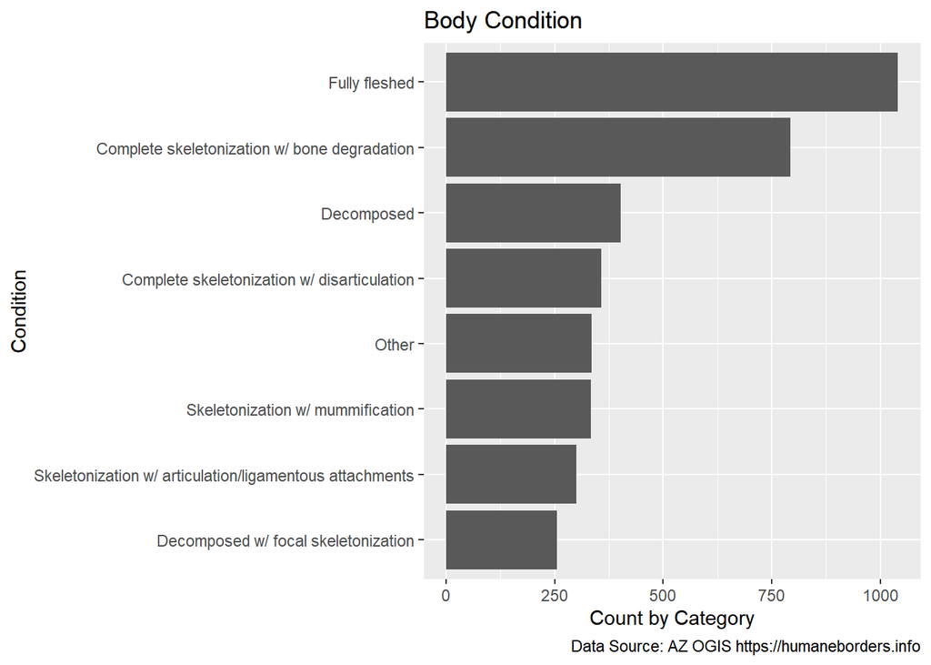

# 7 Post Mortem Interval

| Post Mortem Interval | n |
| --- | --- |
| < 1 day | 1041 |
| > 6-8 months | 793 |
| < 1 week | 402 |
| < 6-8 months | 357 |
| Undetermined | 335 |
| < 5 weeks | 333 |
| < 3 months | 300 |
| < 3 weeks | 255 |

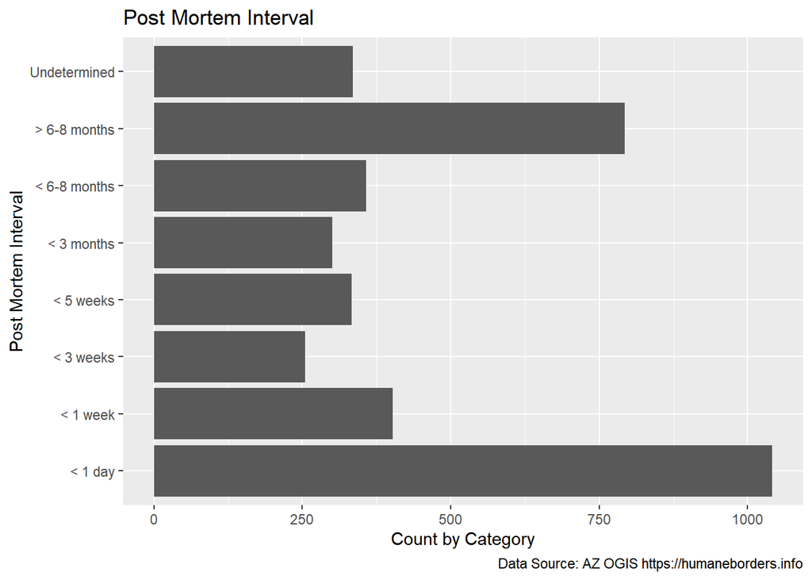